# Evaluating Patient-Reported Adherence and Outcomes in Specialty Disease States: A Dual Site Initiative

# 1 Demographics

| **Characteristic** | **N** | **Site 1**, N = 3346<sup>1</sup> | **Site 2**, N = 331<sup>1</sup> | **Overall**, N = 3677<sup>1</sup> |
| --- | --- | --- | --- | --- |
| Age (at the time of first assessment in study period) | 3677 |  |  |  |
| Mean (SD) |  | 47.3 (18.2) | 50.0 (14.0) | 47.5 (17.9) |
| Median (IQR) |  | 50.0 (37.0 - 61.0) | 50.0 (40.0 - 61.0) | 50.0 (37.0 - 61.0) |
| Range |  | 0.0 - 90.0 | 16.0 - 81.0 | 0.0 - 90.0 |
| Gender | 3677 |  |  |  |
| Female |  | 2374 (71.0%) | 264 (79.8%) | 2638 (71.7%) |
| Male |  | 972 (29.0%) | 67 (20.2%) | 1039 (28.3%) |
| Race | 3677 |  |  |  |
| White |  | 2719 (81.3%) | 61 (18.4%) | 2780 (75.6%) |
| Black or African American |  | 304 (9.09%) | 167 (50.5%) | 471 (12.8%) |
| American Indian or Alaska Native |  | 12 (0.36%) | 2 (0.60%) | 14 (0.38%) |
| Other Asian |  | 27 (0.81%) | 7 (2.11%) | 34 (0.92%) |
| Other |  | 27 (0.81%) | 89 (26.9%) | 116 (3.15%) |
| Decline to Answer |  | 6 (0.18%) | 1 (0.30%) | 7 (0.19%) |
| Unknown |  | 77 (2.30%) | 4 (1.21%) | 81 (2.20%) |
| Chinese |  | 2 (0.06%) | 0 (0%) | 2 (0.05%) |
| Filipino |  | 1 (0.03%) | 0 (0%) | 1 (0.03%) |
| Japanese |  | 1 (0.03%) | 0 (0%) | 1 (0.03%) |
| Korean |  | 2 (0.06%) | 0 (0%) | 2 (0.05%) |
| Asian Indian |  | 4 (0.12%) | 0 (0%) | 4 (0.11%) |
| Other Pacific Islander |  | 5 (0.15%) | 0 (0%) | 5 (0.14%) |
| NULL |  | 159 (4.75%) | 0 (0%) | 159 (4.32%) |
| Ethnicity | 3677 |  |  |  |
| Not Hispanic, Latino/a, or Spanish origin |  | 2967 (88.7%) | 243 (73.4%) | 3210 (87.3%) |
| Hispanic or Latino |  | 1 (0.03%) | 79 (23.9%) | 80 (2.18%) |
| Unknown |  | 35 (1.05%) | 3 (0.91%) | 38 (1.03%) |
| Decline to Answer |  | 11 (0.33%) | 6 (1.81%) | 17 (0.46%) |
| Mexican, Mexican American, or Chicano/a |  | 9 (0.27%) | 0 (0%) | 9 (0.24%) |
| Puerto Rican |  | 4 (0.12%) | 0 (0%) | 4 (0.11%) |
| Cuban |  | 1 (0.03%) | 0 (0%) | 1 (0.03%) |
| Other Hispanic, Latino/a, or Spanish origin |  | 80 (2.39%) | 0 (0%) | 80 (2.18%) |
| NULL |  | 238 (7.11%) | 0 (0%) | 238 (6.47%) |

<sup>1</sup> n (%)

| **Characteristic** | **N** | **Site 1**, N = 3346<sup>1</sup> | **Site 2**, N = 331<sup>1</sup> | **Overall**, N = 3677<sup>1</sup> |
| --- | --- | --- | --- | --- |
| assess_clinic | 3677 |  |  |  |
| MS |  | 798 (23.8%) | 82 (24.8%) | 880 (23.9%) |
| Rheumatology |  | 2546 (76.1%) | 249 (75.2%) | 2795 (76.0%) |
| Rheumatology, MS |  | 2 (0.06%) | 0 (0%) | 2 (0.05%) |

<sup>1</sup> n (%)

## 1.1 Number of Monthly Medication Assessments

There are approximately 30 months of study time.

| **Characteristic** | **N** | **N = 3677** |
| --- | --- | --- |
| n | 3677 |  |
| Mean (SD) |  | 16.8 (10.6) |
| Median (IQR) |  | 16.0 (7.0 - 27.0) |
| Range |  | 1.0 - 63.0 |

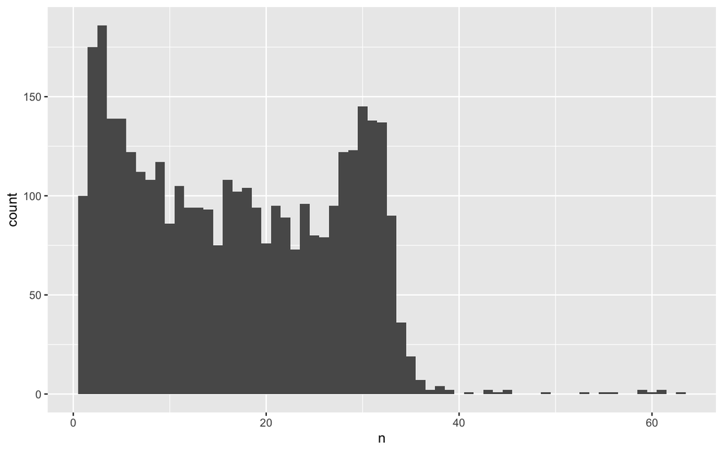

### 1.1.1 Medications assessed by clinic type

| **Characteristic** | **N** | **Rheumatology**, N = 45420<sup>1</sup> | **MS**, N = 16506<sup>1</sup> | **Overall**, N = 61926<sup>1</sup> |
| --- | --- | --- | --- | --- |
| Medication prescribed (radio) | 61926 |  |  |  |
| Cimzia (certolizumab) |  | 787 (1.73%) | 0 (0%) | 787 (1.27%) |
| Humira (adalimumab) |  | 16643 (36.6%) | 17 (0.10%) | 16660 (26.9%) |
| Orencia (abatacept) |  | 2915 (6.42%) | 0 (0%) | 2915 (4.71%) |
| Rasuvo (methotrexate) |  | 0 (0%) | 0 (0%) | 0 (0%) |
| Simponi (golimumab) |  | 641 (1.41%) | 0 (0%) | 641 (1.04%) |
| Stelara (ustekinumab) |  | 151 (0.33%) | 0 (0%) | 151 (0.24%) |
| Xeljanz/Xeljanz XR (tofacitinib) |  | 4408 (9.70%) | 0 (0%) | 4408 (7.12%) |
| Actemra (tocilizumab) |  | 1673 (3.68%) | 0 (0%) | 1673 (2.70%) |
| Benlysta (belimumab) |  | 1107 (2.44%) | 0 (0%) | 1107 (1.79%) |
| Cosentyx (secukinumab) |  | 1879 (4.14%) | 0 (0%) | 1879 (3.03%) |
| Enbrel (etanercept) |  | 11060 (24.4%) | 0 (0%) | 11060 (17.9%) |
| Kevzara (sarilumab) |  | 303 (0.67%) | 0 (0%) | 303 (0.49%) |
| Kineret (anakinra) |  | 869 (1.91%) | 7 (0.04%) | 876 (1.41%) |
| Olumiant (baricitinib) |  | 120 (0.26%) | 0 (0%) | 120 (0.19%) |
| Otezla (apremilast) |  | 1101 (2.42%) | 0 (0%) | 1101 (1.78%) |
| Rinvoq (upadacitinib) |  | 1082 (2.38%) | 0 (0%) | 1082 (1.75%) |
| Taltz (ixekizumab) |  | 681 (1.50%) | 0 (0%) | 681 (1.10%) |
| Ampyra/XR (dalfampridine) |  | 0 (0%) | 1826 (11.1%) | 1826 (2.95%) |
| Aubagio (teriflunomide) |  | 0 (0%) | 1331 (8.06%) | 1331 (2.15%) |
| Avonex (interferon beta-1a) |  | 0 (0%) | 996 (6.03%) | 996 (1.61%) |
| Betaseron (interferon beta-1b) |  | 0 (0%) | 427 (2.59%) | 427 (0.69%) |
| Copaxone (glatiramer acetate) |  | 0 (0%) | 1391 (8.43%) | 1391 (2.25%) |
| Extavia (interferon beta-1b) |  | 0 (0%) | 54 (0.33%) | 54 (0.09%) |
| Gilenya (fingolimod) |  | 0 (0%) | 3065 (18.6%) | 3065 (4.95%) |
| Glatopa (glatiramer acetate) |  | 0 (0%) | 69 (0.42%) | 69 (0.11%) |
| Mayzent (siponimod) |  | 0 (0%) | 30 (0.18%) | 30 (0.05%) |
| Plegridy (peginterferon beta-1a) |  | 0 (0%) | 367 (2.22%) | 367 (0.59%) |
| Rebif (interferon beta-1a) |  | 0 (0%) | 1522 (9.22%) | 1522 (2.46%) |
| Tecfidera (dimethyl fumarate) |  | 0 (0%) | 3373 (20.4%) | 3373 (5.45%) |
| glatiramer acetate |  | 0 (0%) | 1561 (9.46%) | 1561 (2.52%) |
| Otrexup (methotrexate) |  | 0 (0%) | 0 (0%) | 0 (0%) |
| Vumerity (diroximel fumarate) |  | 0 (0%) | 369 (2.24%) | 369 (0.60%) |
| Bafiertam (monomethyl fumarate) |  | 0 (0%) | 45 (0.27%) | 45 (0.07%) |
| Zeposia (ozanimod) |  | 0 (0%) | 56 (0.34%) | 56 (0.09%) |

<sup>1</sup> n (%)

### 1.1.2 Number of patient monthly medication assessments by medication

| Medication prescribed (radio) | total | med.iqr | range |
| --- | --- | --- | --- |
| Cimzia (certolizumab) | 787 | 6 (2, 12.5) | 1, 32 |
| Humira (adalimumab) | 16660 | 13 (5, 25) | 1, 41 |
| Orencia (abatacept) | 2915 | 11 (4, 23) | 1, 34 |
| Simponi (golimumab) | 641 | 7 (2, 16.5) | 1, 33 |
| Stelara (ustekinumab) | 151 | 3 (1, 6) | 1, 17 |
| Xeljanz/Xeljanz XR (tofacitinib) | 4408 | 13 (5, 20) | 1, 32 |
| Actemra (tocilizumab) | 1673 | 10 (3, 20) | 1, 45 |
| Benlysta (belimumab) | 1107 | 10.5 (4, 22) | 1, 33 |
| Cosentyx (secukinumab) | 1879 | 9 (4, 17) | 1, 34 |
| Enbrel (etanercept) | 11060 | 14 (6, 25) | 1, 36 |

[output cut: 22 more lines]

## 1.2 Number of patient reported outcomes (PROs)

| **Characteristic** | **N** | **N = 3677**<sup>1</sup> |
| --- | --- | --- |
| any.missed.doses | 3677 |  |
| No |  | 2418 (65.8%) |
| Yes |  | 1259 (34.2%) |
| any.tolerability | 3660 |  |
| No |  | 3188 (87.1%) |
| Yes |  | 472 (12.9%) |
| Missing |  | 17 |
| any.hosp_er | 3677 |  |
| No |  | 3156 (85.8%) |
| Yes |  | 521 (14.2%) |
| any.fair.poor | 3677 |  |
| No |  | 2621 (71.3%) |
| Yes |  | 1056 (28.7%) |
| any.excellent | 3677 |  |
| No |  | 955 (26.0%) |
| Yes |  | 2722 (74.0%) |

<sup>1</sup> n (%)

# 2 Monthly Medication Assessments

## 2.1 Site

| **Characteristic** | **N** | **N = 61926**<sup>1</sup> |
| --- | --- | --- |
| Research site | 61926 |  |
| Site 1 |  | 57162 (92.3%) |
| Site 2 |  | 4764 (7.69%) |

<sup>1</sup> n (%)

## 2.2 Clinic and medications

| **Characteristic** | **N** | **Site 1**, N = 57162<sup>1</sup> | **Site 2**, N = 4764<sup>1</sup> | **Overall**, N = 61926<sup>1</sup> |
| --- | --- | --- | --- | --- |
| Clinic medication prescribed through | 61926 |  |  |  |
| Rheumatology |  | 42139 (73.7%) | 3281 (68.9%) | 45420 (73.3%) |
| MS |  | 15023 (26.3%) | 1483 (31.1%) | 16506 (26.7%) |
| Medication prescribed (radio) | 61926 |  |  |  |
| Cimzia (certolizumab) |  | 754 (1.32%) | 33 (0.69%) | 787 (1.27%) |
| Humira (adalimumab) |  | 14912 (26.1%) | 1748 (36.7%) | 16660 (26.9%) |
| Orencia (abatacept) |  | 2742 (4.80%) | 173 (3.63%) | 2915 (4.71%) |
| Rasuvo (methotrexate) |  | 0 (0%) | 0 (0%) | 0 (0%) |
| Simponi (golimumab) |  | 595 (1.04%) | 46 (0.97%) | 641 (1.04%) |
| Stelara (ustekinumab) |  | 150 (0.26%) | 1 (0.02%) | 151 (0.24%) |
| Xeljanz/Xeljanz XR (tofacitinib) |  | 4202 (7.35%) | 206 (4.32%) | 4408 (7.12%) |
| Actemra (tocilizumab) |  | 1634 (2.86%) | 39 (0.82%) | 1673 (2.70%) |
| Benlysta (belimumab) |  | 1086 (1.90%) | 21 (0.44%) | 1107 (1.79%) |
| Cosentyx (secukinumab) |  | 1794 (3.14%) | 85 (1.78%) | 1879 (3.03%) |
| Enbrel (etanercept) |  | 10306 (18.0%) | 754 (15.8%) | 11060 (17.9%) |
| Kevzara (sarilumab) |  | 289 (0.51%) | 14 (0.29%) | 303 (0.49%) |
| Kineret (anakinra) |  | 876 (1.53%) | 0 (0%) | 876 (1.41%) |
| Olumiant (baricitinib) |  | 113 (0.20%) | 7 (0.15%) | 120 (0.19%) |
| Otezla (apremilast) |  | 1005 (1.76%) | 96 (2.02%) | 1101 (1.78%) |
| Rinvoq (upadacitinib) |  | 1056 (1.85%) | 26 (0.55%) | 1082 (1.75%) |
| Taltz (ixekizumab) |  | 649 (1.14%) | 32 (0.67%) | 681 (1.10%) |
| Ampyra/XR (dalfampridine) |  | 1826 (3.19%) | 0 (0%) | 1826 (2.95%) |
| Aubagio (teriflunomide) |  | 1243 (2.17%) | 88 (1.85%) | 1331 (2.15%) |
| Avonex (interferon beta-1a) |  | 936 (1.64%) | 60 (1.26%) | 996 (1.61%) |
| Betaseron (interferon beta-1b) |  | 335 (0.59%) | 92 (1.93%) | 427 (0.69%) |
| Copaxone (glatiramer acetate) |  | 1289 (2.25%) | 102 (2.14%) | 1391 (2.25%) |
| Extavia (interferon beta-1b) |  | 54 (0.09%) | 0 (0%) | 54 (0.09%) |
| Gilenya (fingolimod) |  | 2875 (5.03%) | 190 (3.99%) | 3065 (4.95%) |
| Glatopa (glatiramer acetate) |  | 69 (0.12%) | 0 (0%) | 69 (0.11%) |
| Mayzent (siponimod) |  | 30 (0.05%) | 0 (0%) | 30 (0.05%) |
| Plegridy (peginterferon beta-1a) |  | 367 (0.64%) | 0 (0%) | 367 (0.59%) |
| Rebif (interferon beta-1a) |  | 1391 (2.43%) | 131 (2.75%) | 1522 (2.46%) |
| Tecfidera (dimethyl fumarate) |  | 2783 (4.87%) | 590 (12.4%) | 3373 (5.45%) |
| glatiramer acetate |  | 1341 (2.35%) | 220 (4.62%) | 1561 (2.52%) |
| Otrexup (methotrexate) |  | 0 (0%) | 0 (0%) | 0 (0%) |
| Vumerity (diroximel fumarate) |  | 369 (0.65%) | 0 (0%) | 369 (0.60%) |
| Bafiertam (monomethyl fumarate) |  | 45 (0.08%) | 0 (0%) | 45 (0.07%) |
| Zeposia (ozanimod) |  | 46 (0.08%) | 10 (0.21%) | 56 (0.09%) |

<sup>1</sup> n (%)

## 2.3 Missed doses

### 2.3.1 Summary

| **Characteristic** | **N** | **Site 1**, N = 57162<sup>1</sup> | **Site 2**, N = 4764<sup>1</sup> | **Overall**, N = 61926<sup>1</sup> |
| --- | --- | --- | --- | --- |
| Have you missed doses of your medication this month? | 61926 |  |  |  |
| Yes |  | 1861 (3.26%) | 621 (13.0%) | 2482 (4.01%) |
| No |  | 55300 (96.7%) | 3890 (81.7%) | 59190 (95.6%) |
| Data not available (NULL) |  | 1 (<0.01%) | 253 (5.31%) | 254 (0.41%) |

<sup>1</sup> n (%)

### 2.3.2 Reasons

| label | Site 1 | Site 2 | Total | Site 1_pct | Site 2_pct | Total_pct |
| --- | --- | --- | --- | --- | --- | --- |
| Total | 1889 | 633 | 2522 | 1889 (100%) | 633 (100%) | 2522 (100%) |
| Forgetfulness | 556 | 280 | 836 | 556 (29.4%) | 280 (44.2%) | 836 (33.1%) |
| Purposefully held | 674 | 70 | 744 | 674 (35.7%) | 70 (11.1%) | 744 (29.5%) |
| Other | 224 | 59 | 283 | 224 (11.9%) | 59 (9.3%) | 283 (11.2%) |
| Ran out of medication | 191 | 73 | 264 | 191 (10.1%) | 73 (11.5%) | 264 (10.5%) |
| No reason documented | 34 | 82 | 116 | 34 (1.8%) | 82 (13%) | 116 (4.6%) |
| Hospitalized | 78 | 20 | 98 | 78 (4.1%) | 20 (3.2%) | 98 (3.9%) |
| Medication remaining but not available | 30 | 29 | 59 | 30 (1.6%) | 29 (4.6%) | 59 (2.3%) |
| COVID-19 | 53 | 3 | 56 | 53 (2.8%) | 3 (0.5%) | 56 (2.2%) |
| Financial or insurance barrier | 22 | 11 | 33 | 22 (1.2%) | 11 (1.7%) | 33 (1.3%) |

[output cut: 3 more lines]

### 2.3.3 Figures

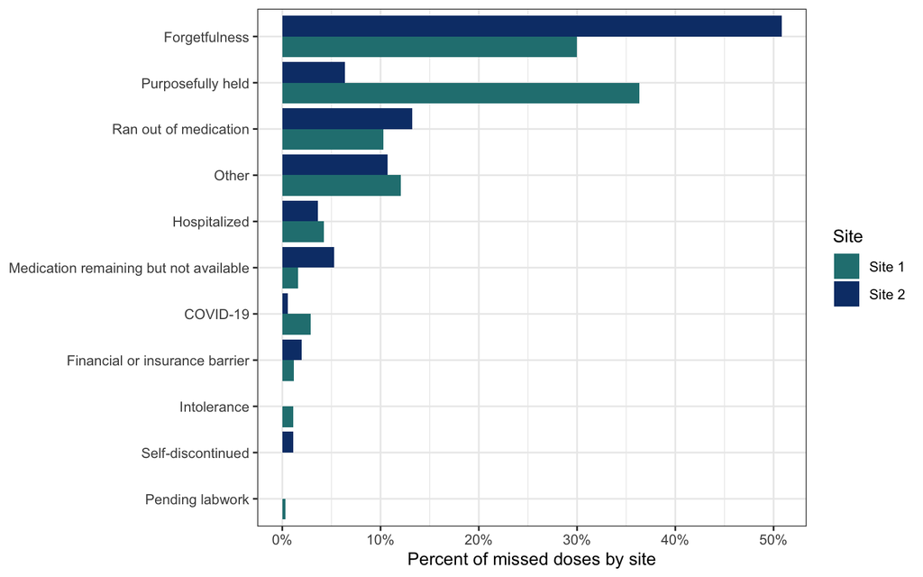

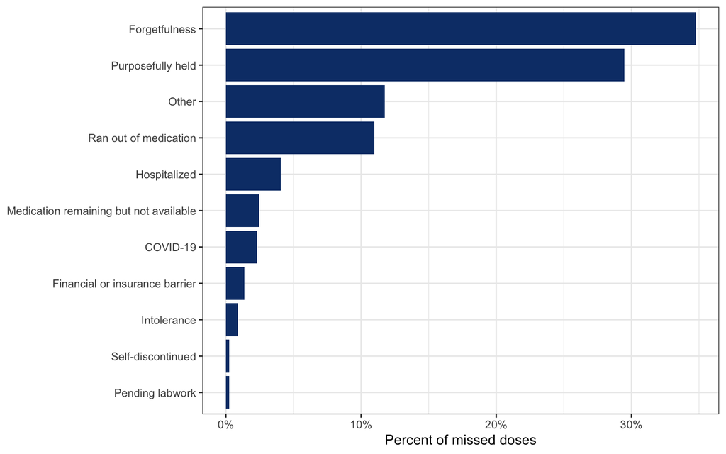

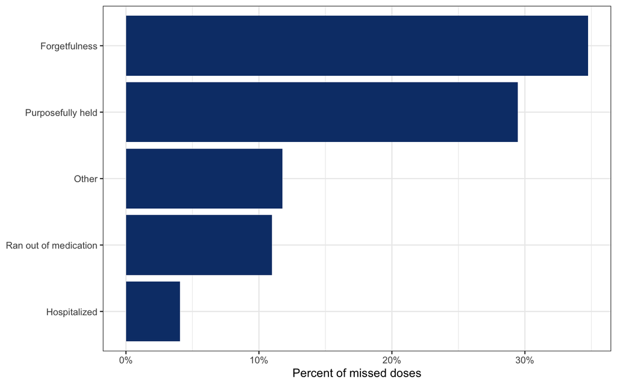

### 2.3.4 Intersections

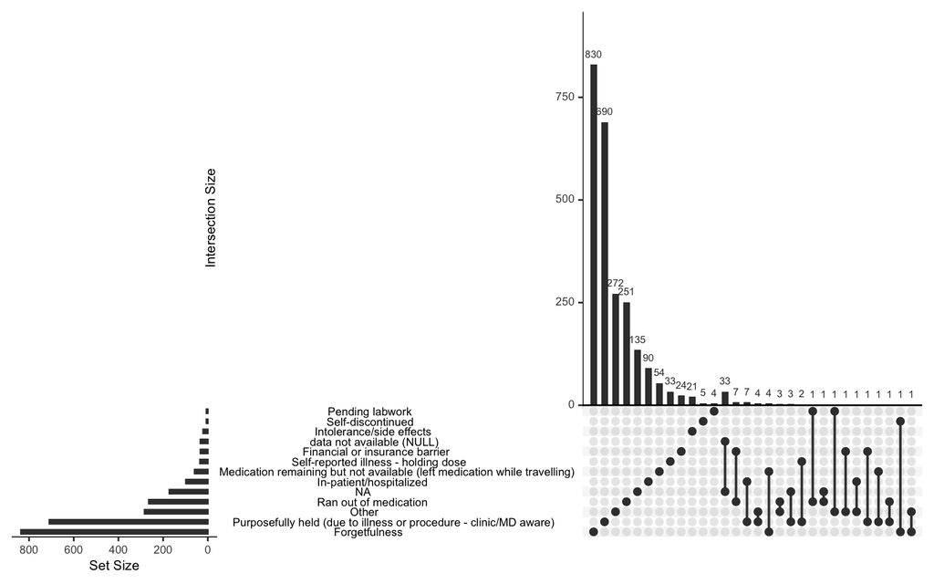

## 2.4 Tolerability

| **Characteristic** | **N** | **Site 1**, N = 57162<sup>1</sup> | **Site 2**, N = 4764<sup>1</sup> | **Overall**, N = 61926<sup>1</sup> |
| --- | --- | --- | --- | --- |
| Site 1: Are you experiencing any side effects? Site 2: Have you had any problems tolerating the medication? | 61835 |  |  |  |
| Yes |  | 519 (0.91%) | 170 (3.57%) | 689 (1.11%) |
| No |  | 56552 (99.1%) | 4340 (91.1%) | 60892 (98.5%) |
| Data not available (NULL) |  | 0 (0%) | 254 (5.33%) | 254 (0.41%) |
| Missing |  | 91 | 0 | 91 |

<sup>1</sup> n (%)

## 2.5 Effectiveness / hospitalizations

| **Characteristic** | **N** | **Site 1**, N = 57162<sup>1</sup> | **Site 2**, N = 4764<sup>1</sup> | **Overall**, N = 61926<sup>1</sup> |
| --- | --- | --- | --- | --- |
| Since we last spoke for your refill, have you been hospitalized or had to visit the ER or ED for any reason? | 61926 |  |  |  |
| Yes |  | 567 (0.99%) | 191 (4.01%) | 758 (1.22%) |
| No |  | 55673 (97.4%) | 4318 (90.6%) | 59991 (96.9%) |
| Data not available (NULL) |  | 922 (1.61%) | 255 (5.35%) | 1177 (1.90%) |
| How well do you think your medication is working for you? | 61926 |  |  |  |
| Excellent |  | 13055 (22.8%) | 1230 (25.8%) | 14285 (23.1%) |
| Good |  | 41409 (72.4%) | 2422 (50.8%) | 43831 (70.8%) |
| Fair |  | 1608 (2.81%) | 793 (16.6%) | 2401 (3.88%) |
| Poor |  | 122 (0.21%) | 34 (0.71%) | 156 (0.25%) |
| NULL/Data not available |  | 968 (1.69%) | 285 (5.98%) | 1253 (2.02%) |

<sup>1</sup> n (%)

## 2.6 Missed doses and tolerability

| **Characteristic** | **N** | **Missed doses** **Yes**, N = 2478<sup>1</sup> | **Missed doses** **No**, N = 59100<sup>1</sup> | **p-value**<sup>2</sup> | **Overall**, N = 61578<sup>1</sup> |  |  |
| --- | --- | --- | --- | --- | --- | --- | --- |
| Site 1: Are you experiencing any side effects? Site 2: Have you had any problems tolerating the medication? | 61578 |  |  |  |  | <0.001 |  |
| Yes |  | 102 (4.12%) | 587 (0.99%) |  | 689 (1.12%) |  |  |
| No |  | 2376 (95.9%) | 58513 (99.0%) |  | 60889 (98.9%) |  |  |

<sup>1</sup> n (%)  
<sup>2</sup> Pearson's Chi-squared test

## 2.7 Missed doses and effectiveness

| **Characteristic** | **N** | **Missed doses** **Yes**, N = 2433<sup>1</sup> | **Missed doses** **No**, N = 58240<sup>1</sup> | **p-value**<sup>2</sup> | **Overall**, N = 60673<sup>1</sup> |  |  |
| --- | --- | --- | --- | --- | --- | --- | --- |
| How well do you think your medication is working for you? | 60673 |  |  |  |  | <0.001 |  |
| Excellent |  | 479 (19.7%) | 13806 (23.7%) |  | 14285 (23.5%) |  |  |
| Good |  | 1711 (70.3%) | 42120 (72.3%) |  | 43831 (72.2%) |  |  |
| Fair |  | 234 (9.62%) | 2167 (3.72%) |  | 2401 (3.96%) |  |  |
| Poor |  | 9 (0.37%) | 147 (0.25%) |  | 156 (0.26%) |  |  |

<sup>1</sup> n (%)  
<sup>2</sup> Pearson's Chi-squared test

## 2.8 Missed doses and hosp/er

| **Characteristic** | **N** | **Missed doses** **Yes**, N = 2440<sup>1</sup> | **Missed doses** **No**, N = 58306<sup>1</sup> | **p-value**<sup>2</sup> | **Overall**, N = 60746<sup>1</sup> |  |  |
| --- | --- | --- | --- | --- | --- | --- | --- |
| Since we last spoke for your refill, have you been hospitalized or had to visit the ER or ED for any reason? | 60746 |  |  |  |  | <0.001 |  |
| Yes |  | 200 (8.20%) | 558 (0.96%) |  | 758 (1.25%) |  |  |
| No |  | 2240 (91.8%) | 57748 (99.0%) |  | 59988 (98.8%) |  |  |

<sup>1</sup> n (%)  
<sup>2</sup> Pearson's Chi-squared test

### 2.8.1 Missingness

| **Characteristic** | **N** | **Missing missed_doses** **No**, N = 61672<sup>1</sup> | **Missing missed_doses** **Yes**, N = 254<sup>1</sup> | **Overall**, N = 61926<sup>1</sup> |  |
| --- | --- | --- | --- | --- | --- |
| missing.hosp_er | 61926 |  |  |  |  |
| No |  | 60746 (98.5%) | 3 (1.18%) | 60749 (98.1%) |  |
| Yes |  | 926 (1.50%) | 251 (98.8%) | 1177 (1.90%) |  |

<sup>1</sup> n (%)

# 3 Analyses

## 3.1 Missed doses

We found strong evidence of a nonlinear association between age and reported missed doses (p < 0.001), with the highest likelihood of a missed dose occurring at roughly 40 years. Males were 28% less likely than females to report a missed dose at any MMA (OR = 0.72, 95% CI 0.61 - 0.85, p <0.001). The additional MMA outcomes were highly associated with a reported missed dose as well, with people who reported a hospitalization being 8.4 times more likely to report a missed dose than those who did not report one (OR = 8.42, 95% CI 6.82 - 10.39, p < 0.001). The odds ratio of reporting a missed dose increased to 2.46 when tolerability issues were reported (95% CI 1.87 - 3.23, p <0.001). An effectiveness rating of ‘Fair’ was associated with a 61% increase in the odds of a missed dose compared to a rating of “Good/ Excellent” (OR 1.61, 95% CI 1.33 - 1.94). We also found evidence of a very strong site effect (p < 0.001), likely due to the way the MMAs are administered across sites.

### 3.1.1 Results

| label | level | Odds ratio (95% CI) | p.value | df | anova.p |
| --- | --- | --- | --- | --- | --- |
| Age (nonlinear) | Overall | NA | NA | 4 | <0.001 |
| Clinic | MS vs Rheumatology | 0.97 (0.82 - 1.14) | 0.712 | NA | NA |
| Effectiveness | Fair vs. Good/Excellent | 1.61 (1.33 - 1.94) | <0.001 | NA | NA |
| Effectiveness | Poor vs. Good/Excellent | 0.97 (0.44 - 2.12) | 0.937 | NA | NA |
| Effectiveness | Overall | NA | NA | 2 | <0.001 |
| Gender | Male vs. Female | 0.72 (0.61 - 0.85) | <0.001 | NA | NA |
| Hospitalization | Yes vs. No | 8.42 (6.82 - 10.39) | <0.001 | NA | NA |
| Race | White vs. Black | 0.86 (0.69 - 1.08) | 0.199 | NA | NA |
| Race | Other vs. Black | 0.95 (0.67 - 1.34) | 0.757 | NA | NA |
| Race | Overall | NA | NA | 2 | 0.434 |

[output cut: 2 more lines]

**The predicted effects in the following plots are based off of an incorrectly specified model. These are for illustrative purposes only**

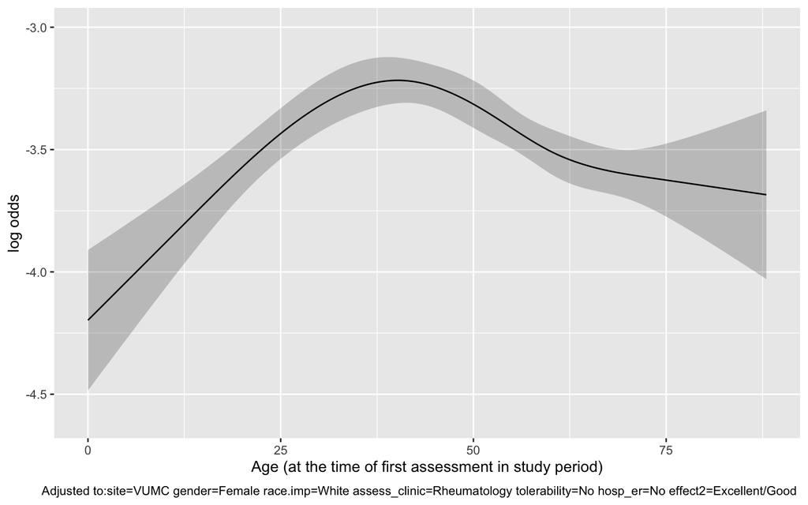

## 3.2 Tolerability

### 3.2.1 Results

| label | level | Odds ratio (95% CI) | p.value | df | anova.p |
| --- | --- | --- | --- | --- | --- |
| Age (nonlinear) | Overall | NA | NA | 4 | 0.063 |
| Clinic | MS vs Rheumatology | 1.46 (1.07 - 2) | 0.018 | NA | NA |
| Effectiveness | Fair vs. Good/Excellent | 5.41 (4.17 - 7.02) | <0.001 | NA | NA |
| Effectiveness | Poor vs. Good/Excellent | 12.35 (6.26 - 24.37) | <0.001 | NA | NA |
| Effectiveness | Overall | NA | NA | 2 | <0.001 |
| Gender | Male vs. Female | 0.63 (0.46 - 0.87) | 0.005 | NA | NA |
| Hospitalization | Yes vs. No | 1.93 (1.23 - 3.03) | 0.004 | NA | NA |
| Missed doses | Yes vs. No | 2.38 (1.79 - 3.15) | <0.001 | NA | NA |
| Race | Other vs. Black | 1.39 (0.73 - 2.62) | 0.317 | NA | NA |
| Race | White vs. Black | 0.87 (0.57 - 1.33) | 0.513 | NA | NA |

[output cut: 2 more lines]

**The predicted effects in the following plots are based off of an incorrectly specified model. These are for illustrative purposes only**

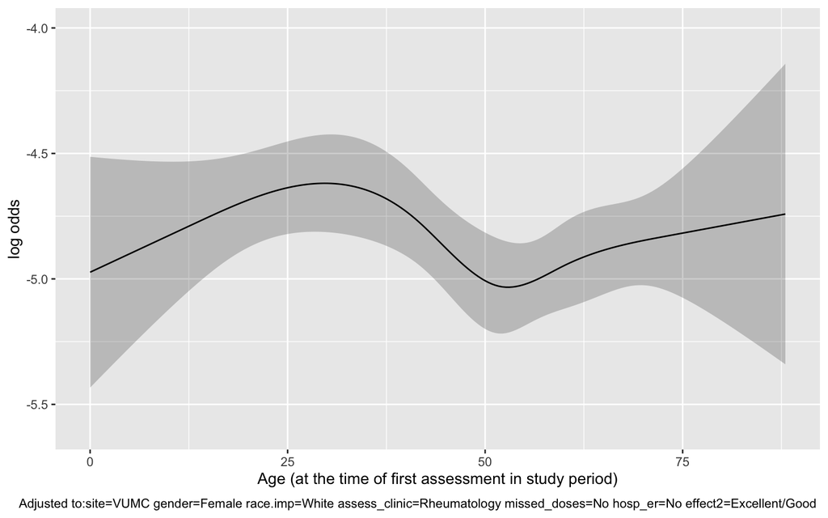

## 3.3 Hospitalization

### 3.3.1 Results

| label | level | Odds ratio (95% CI) | p.value | df | anova.p |
| --- | --- | --- | --- | --- | --- |
| Age (nonlinear) | Overall | NA | NA | 4 | <0.001 |
| Clinic | MS vs Rheumatology | 1.29 (1 - 1.66) | 0.050 | NA | NA |
| Effectiveness | Fair vs. Good/Excellent | 2.1 (1.58 - 2.79) | <0.001 | NA | NA |
| Effectiveness | Poor vs. Good/Excellent | 2.09 (0.77 - 5.67) | 0.148 | NA | NA |
| Effectiveness | Overall | NA | NA | 2 | <0.001 |
| Gender | Male vs. Female | 0.77 (0.6 - 1) | 0.046 | NA | NA |
| Missed doses | Yes vs. No | 8.16 (6.64 - 10.02) | <0.001 | NA | NA |
| Race | Other vs. Black | 0.57 (0.33 - 1) | 0.051 | NA | NA |
| Race | White vs. Black | 0.86 (0.61 - 1.21) | 0.385 | NA | NA |
| Race | Overall | NA | NA | 2 | 0.14 |

[output cut: 2 more lines]

**The predicted effects in the following plots are based off of an incorrectly specified model. These are for illustrative purposes only**

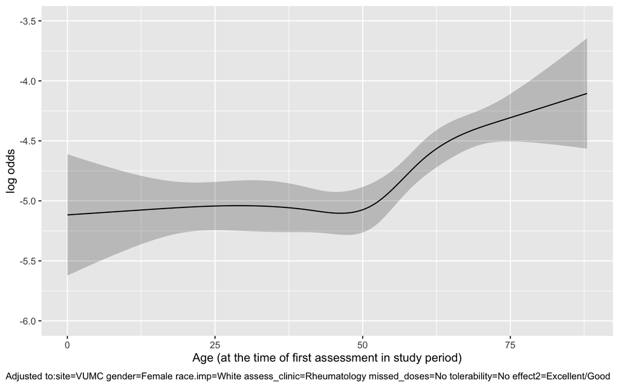

## 3.4 Effectiveness

### 3.4.1 Results

| label | level | Odds ratio (95% CI) | p.value |
| --- | --- | --- | --- |
| Gender | Male vs. Female | 0.82 (0.66 - 1.01) | 0.067 |
| Race | Other vs. Black | 0.76 (0.47 - 1.23) | 0.269 |
| Race | White vs. Black | 0.81 (0.59 - 1.11) | 0.186 |
| Clinic | MS vs Rheumatology | 0.32 (0.25 - 0.41) | <0.001 |
| Site | Site 2 vs. Site 1 | 8.24 (5.74 - 11.84) | <0.001 |
| Missed doses | Yes vs. No | 1.59 (1.32 - 1.92) | <0.001 |
| Tolerability | Yes vs. No | 5.18 (4.02 - 6.68) | <0.001 |
| Hospitalization | Yes vs. No | 2.06 (1.55 - 2.74) | <0.001 |

**Test for significance of non-linear age effect**

```
## Likelihood ratio tests of cumulative link models
##
## Response: effect2
##                                                                                                  Model
## 1         gender + race.imp + age + assess_clinic + site + missed_doses + tolerability + hosp_er |  |
## 2 gender + race.imp + rcs(age, 5) + assess_clinic + site + missed_doses + tolerability + hosp_er |  |
##   Resid. df -2logLik   Test    Df LR stat.      Pr(Chi)
## 1     60569 17630.29
## 2     60566 17604.04 1 vs 2     3 26.24889 8.458856e-06
```

**The predicted effects in the following plots are based off of an incorrectly specified model. These are for illustrative purposes only**

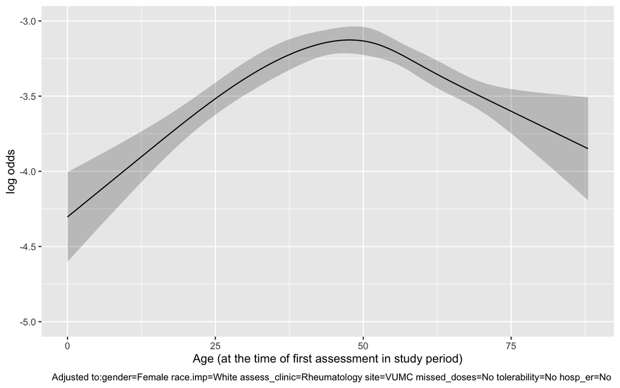